## Adverse Events for PREDNISONE Report - This report is for testing and informational purposes only.

Top 10 most frequent adverse events for people taking PREDNISONE with drug indication of Lupus are:

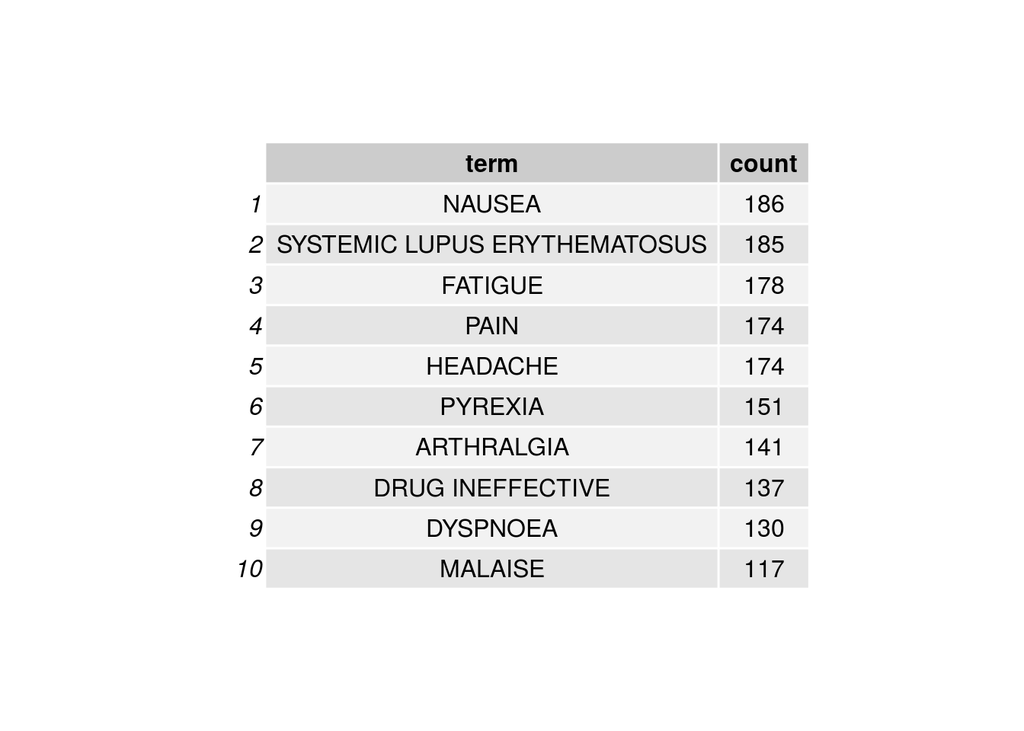

## Adverse Events Information

The graph below displays the top 5 adverse events for 3 different drugs as reported 2004 to 2015 for women aged 50-60 with drug indication of Lupus.

The chart below is made with the `ggplot2` and `plotly` R packages, widely used packages for graphics and visualizing data in R. You can learn more about `ggplot2` and `plotly` at each packages website. Data are extracted from the OpenFDA API using the `openfda` R package. You can read more via the github page.

[interactive chart not shown]

## Raw Data

|  | term | count | drug |
| --- | --- | --- | --- |
| 1 | HEADACHE | 18 | PREDNISONE |
| 2 | FATIGUE | 16 | PREDNISONE |
| 3 | NAUSEA | 15 | PREDNISONE |
| 4 | PYREXIA | 14 | PREDNISONE |
| 5 | DIARRHOEA | 13 | PREDNISONE |
| 6 | PAIN | 20 | Hydroxychloroquine |
| 7 | NAUSEA | 20 | Hydroxychloroquine |
| 8 | FATIGUE | 19 | Hydroxychloroquine |
| 9 | HEADACHE | 18 | Hydroxychloroquine |
| 10 | DIARRHOEA | 15 | Hydroxychloroquine |

[output cut: 5 more lines]

## Male / Female Outcomes Information for PREDNISONE Report

The graph below displays the outcome of the reaction or event at the time of last observation for reports that were first received 2004 - 2015 and for 50-60 years of age and by sex for PREDNISONE.

[interactive chart not shown]

[output not shown]

[output not shown]

[output not shown]

As found here: https://open.fda.gov/drug/event/ and here: https://open.fda.gov/drug/event/reference/

Responsible use of the data

openFDA is in beta and is a beta research project and not for clinical use.

Adverse event reports submitted to FDA do not undergo extensive validation or verification. Therefore, a causal relationship cannot be established between product and reactions listed in a report. While a suspected relationship may exist, it is not medically validated and should not be the sole source of information for clinical decision making or other assumptions about the safety or efficacy of a product.

Additionally, it is important to remember that adverse event reports represent a small percentage of total usage numbers of a product. Common products may have a higher number of adverse events due to the higher total number of people using the product. In recent years the FDA has undertaken efforts to increase collection of adverse events. Increases in the total number of adverse events is likely caused by improved reporting.